# MARLOWE with PEAKS on Sample set: multi_file_PEAKS_test Sample ID: Rcom_9_M4_AM_R1

# Filtering tag matches

Filtering counts for all files

```r
strong_count_files <-
  list.files(path = database_query_output_folder,
             pattern = "*._strong_counts.csv",
             full.names = TRUE)

raw_pep_files <- list.files(path = database_query_output_folder,
             pattern = "*._peptide_matches.csv",
             full.names = TRUE)

filt_count_files <-
  purrr::map2(strong_count_files,
              raw_pep_files,
              filter_counts,
              min_pep_per_prot = 2,
              output_dir = filtered_counts_folder)
```

```
[1] "Starting Dataset: 555510-DeNovo"
[1] "Starting with 1753 tag PSMs"
[1] "Filtering removed 1325 tags resulting in 428 tags"
[1] "Starting Dataset: 555558-DeNovo"
[1] "Starting with 2141 tag PSMs"
[1] "Filtering removed 2127 tags resulting in 14 tags"
[1] "Starting Dataset: Fish-DeNove"
[1] "Starting with 3853 tag PSMs"
[1] "Filtering removed 3195 tags resulting in 658 tags"
[1] "Starting Dataset: Juice-DeNovo"
[1] "Starting with 3738 tag PSMs"
[1] "Filtering removed 2552 tags resulting in 1186 tags"
[1] "Starting Dataset: Milk-DeNovo"
[1] "Starting with 1897 tag PSMs"
[1] "Filtering removed 1361 tags resulting in 536 tags"
[1] "Starting Dataset: Oyster-DeNovo"
[1] "Starting with 3409 tag PSMs"
[1] "Filtering removed 2068 tags resulting in 1341 tags"
[1] "Starting Dataset: Rcom_1_M0_AM_R1_7Mar16_Samwise_15-08-55"
[1] "Starting with 180 tag PSMs"
[1] "Filtering removed 123 tags resulting in 57 tags"
[1] "Starting Dataset: Rcom_9_M4_AM_R1_7Mar16_Samwise_15-08-55"
[1] "Starting with 573 tag PSMs"
[1] "Filtering removed 406 tags resulting in 167 tags"
[1] "Starting Dataset: Rcom_GCH4_1_2_03Jun16_Samwise_16-03-32"
[1] "Starting with 1624 tag PSMs"
[1] "Filtering removed 962 tags resulting in 662 tags"
[1] "Starting Dataset: Rcom_GCH4_1_2"
[1] "Starting with 1624 tag PSMs"
[1] "Filtering removed 962 tags resulting in 662 tags"
```

# Scoring organisms

If `fasta_for_filter_path` is not NULL all tags that are found within the specified fasta file are removed.

`min_group_hits` is used to filter taxonomic groups before scoring. If a taxonomic group has total hits < `min_group_hits` it is removed prior to calculating pos_scores and org_scores. If there is only one taxonomic group that passes the `min_group_hits` filter then pos_scores and org_scores won’t be calculated and those columns won’t exist in the output.

For more information use `?run_organism_scoring`.

```r
#overlap matrices and organism_metadata should already be loaded
filt_files <-
  list.files(path = filtered_counts_folder,
             pattern = "_filt_sample_counts.csv",
             full.names = TRUE)

score_files <- purrr::map(
    filt_files,
    run_organism_scoring,
    fasta_for_filter = "crap.fasta",
    organism_metadata_df = organism_metadata,
    scoring_overlap_mat = overlap_mat_for_scoring,
    output_dir = taxonomic_scores_output_folder,
    Pthrsh = 0.4,
    min_total_tags = 10,
    min_total_strong_tags = 10,
    min_organism_strong_tags = 1,
    min_group_hits = 1,
    export_matrix = TRUE
  )
```

```
[1] "~~~~~~~~~~~~~~~~~~~~~~~~~~~~~~~~~~~~~~~~~~~~~~~~~~~~"
[1] "Starting Dataset: 555510-DeNovo"
[1] "Starting with 428 tags."
[1] "Checking tags against crap.fasta"
[1] "0 tags matched to the fasta and were removed. 428 remain."
[1] "Beginning strong tag filter"
[1] "Starting with 428 tags."
[1] "421 strong tags and 2 organisms remain with min_organism_strong_tags = 1"
[1] "run_organism_scoring is saving scores to: /home/danvogel/R/test_uniprot/taxonomic_scores/555510-DeNovo_reduced_matrix.csv"
[1] "Calculating taxonomic group scores..."
[1] "assign_tags() has 421 input tags."
[1] "2 taxonomic groups passed the minimum hits threshold of 1"
  1 4
1 1 0
4 0 1
```

[output cut: 151 more lines]

# Generating Heatmaps

## Organism level heatmap

Set `min_pos_score` and `min_org_hits` parameters to prevent too many organisms from being included in the plot. The values of these parameters will be included in the output filename.

Use the `overlap_mat` generated in Chunk 4: generate-matrices-and-taxon-groups to visualize the overlap coefficients based on all peptides. Use the `overlap_mat_for_scoring` to visualize the overlap coefficients based on strong peptides only.

```r
target_score_file_path <- score_files[[8]]

#load overlap_mat
# load()

omap <- organism_heatmap(score_file_path = target_score_file_path,
                      overlap_matrix = overlap_mat,
                      output_dir = "heatmaps",
                      output_type = "png",
                      min_org_hits = 1,
                      min_pos_score = 1,
                      width = 10,
                      height = 7,
                      units = "in")
```

```
[1] "Starting Rcom_9_M4_AM_R1_7Mar16_Samwise_15-08-55"
```

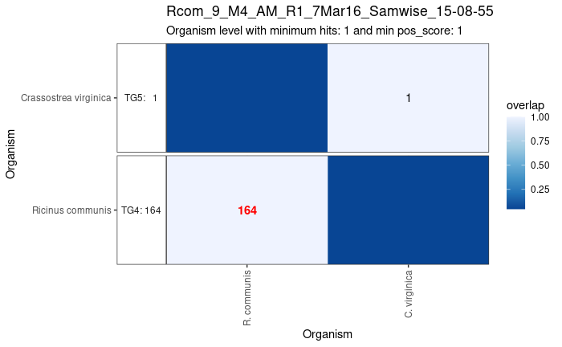

```r
plot(omap)
```